# Summary Report

# Introduction

This document provides summary for processing and filtering one raw VCF file (/home/brb/testdata/GSE48215subset/output/bt20_raw.vcf) as well as annotating the filtered VCF file through the Somatic Mutation Annotator through SnpEff in BRB-SeqTools. We generate the following files in the variant annotation process:

- A gene list (/home/brb/testdata/GSE48215subset/output/snpeff/bt20_raw_genelist.txt) containing nonsynonymous and splicing variants which are not known polymorphisms unless in COSMIC.
- An annotation table (/home/brb/testdata/GSE48215subset/output/snpeff/bt20_raw_annoTable.txt) for the detected variants.
- An annotated VCF file (/home/brb/testdata/GSE48215subset/output/snpeff/bt20_raw_annotated.vcf) associated with the annotation table.

# Variant Annotation Process

The raw VCF file is processed and filtered in the following steps:

1. We keep those variants that pass the criterion that the variant call quality QUAL >= 20, the read depth DP >= 5 and the mapping quality MQ >= 1.
2. We decompose and left normalize the remaining variants.
3. We remove those variants reported in dbSNP database but keep those variants reported in COSMIC database.
4. Nonsynonymous and splicing variants are identified from the remaining variants for further analyses.
5. The remaining variants are annotated through SnpEff.
6. A gene list is retrieved for the variants through SnpEff, which may be a potential list related with the data of interest.

# Summary Statistics

Table 1 summarizes the stastics related with the variant annotation process via SnpEff.

Table 1. Statistics summary associated witht the variant annotation via SnpEff.

| Statistics | Count |
| --- | --- |
| Total number of variants in the raw VCF file | 1610 |
| Number of variants left after the filter by QUAL >= 20, DP >= 5, MQ >= 1 | 331 |
| Number of variants remaining after removing variants reported in dbSNP while keeping variants in COSMIC | 139 |
| Number of variants (out of 139 variants) that are nonsynonymous or splicing ones | 24 |
| Number of variants (out of 24 variants) that are reported in COSMIC | 20 |
| Number of genes associated with 24 variants | 18 |

We also provide a statistics table for the nonsynonymous and splicing variants kept for annotation. Table 2 summarizes the effects the nonsynonymous variants have.

Table 2. Nonsynonymous and splicing variants after filtering.

| Region | Effect | Count |
| --- | --- | --- |
| Exonic | Frameshift | 0 |
| Exonic | Stop loss | 0 |
| Exonic | Stop gain | 0 |
| Exonic | Start loss | 0 |
| Exonic | Mis-sense | 20 |
| Exonic | Disruptive inframe insertion | 0 |
| Exonic | Discruptve inframe deletion | 1 |
| Exonic | Inframe insertion | 2 |
| Exonic | Inframe deletion | 1 |
| Splicing | / | 0 |
| Total | / | 24 |

# Charts

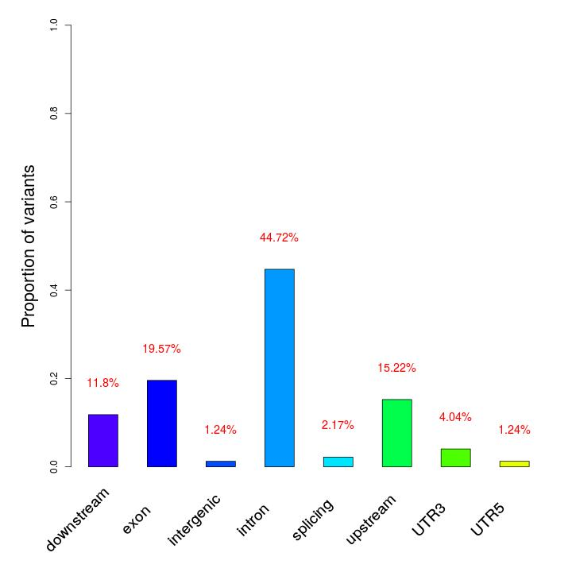

Figure 1. Proportion of variants that hit different regions.

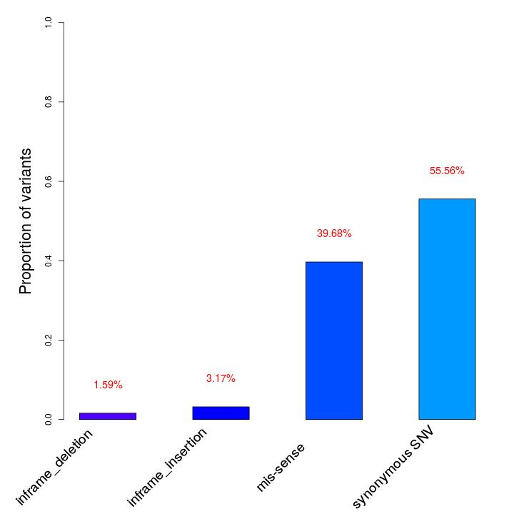

Figure 2. Proportion of exonic variants with their functional effects.